# Lab 9

Joshua Driscoll

11/10/2021

- Q 1

- Q 2

```r
library(here)
birds = read.csv(here("data", "bird.sta.csv"))
hab = read.csv(here("data", "hab.sta.csv"))
birdhab = merge(birds, hab, by = c("basin", "sub", "sta"))
table(birdhab$s.edge, birdhab$BRCR>0)
```

```
##
##     FALSE TRUE
##   E   144   29
##   I   559  314
```

```r
br_creeper_table = table(birdhab$s.edge, birdhab$BRCR > 0)[, 2:1]
chisq.test(br_creeper_table)
```

```
##
##  Pearson's Chi-squared test with Yates' continuity correction
##
## data:  br_creeper_table
## X-squared = 23.3, df = 1, p-value = 1.386e-06
```

Given that we have a very low p value (p = .000001386), we have sufficient evidence to reject the null hypothesis that there is no relationship between the variables. Therefore we can say that there is strong evidence to support the claim that Brown Creeper show habitat preference.

- Q 3

```r
library(palmerpenguins)
fit_species = lm(formula = body_mass_g ~ species, data = penguins)
```

- Q 4

```r
fit_sex = lm(formula = body_mass_g ~ sex, data = penguins)
```

- Q 5

```r
fit_both = lm(formula = body_mass_g ~ species*sex, data = penguins)
```

- Q 6

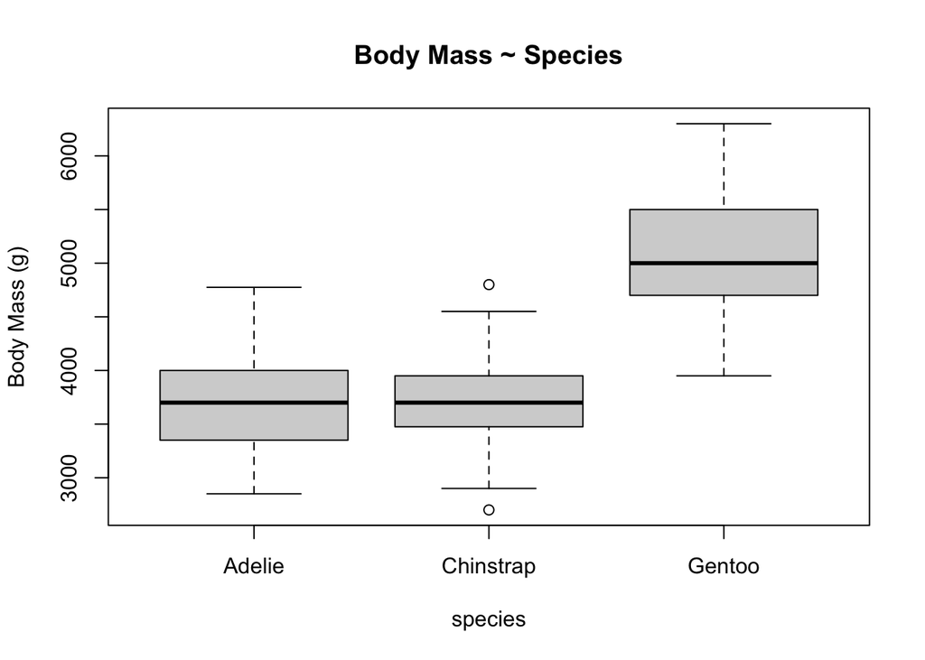

```r
boxplot(body_mass_g ~ species, data = penguins, main = "Body Mass ~ Species", ylab = "Body Mass (g)")
```

- Q 7

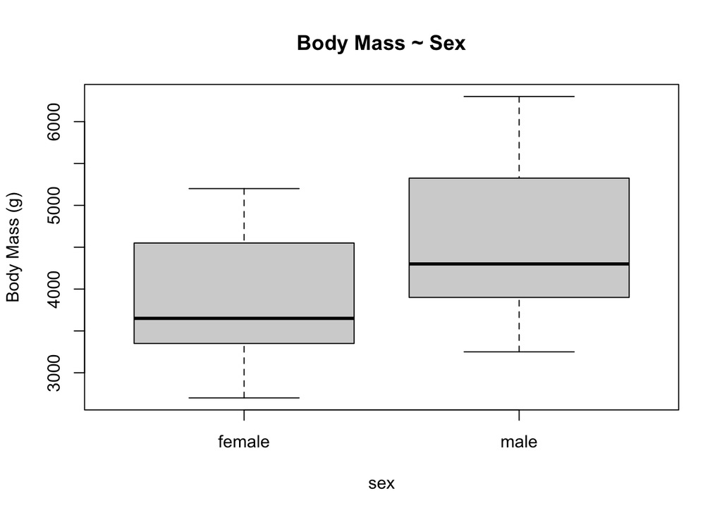

```r
boxplot(body_mass_g ~ sex, data = penguins, main = "Body Mass ~ Sex", ylab = "Body Mass (g)")
```

- Q 8

[figure not shown]

```r
par(las = 2)
boxplot(body_mass_g ~ species*sex, data = penguins, main = "Body Mass ~ Sex and Species", xlab = " ", ylab = "Body Mass (g)", names = c("Female\nAdelie", "Male\nAdelie", "Female\nChinstrap", "Male\nChinstrap", "Female\nGentoo", "Male\nGentoo"))
```

- Q 9

- Q 10

The null hypothesis of the bartlett test is that the variance is equal for all samples.

- Q 11

```r
bartlett.test(body_mass_g ~ species, data = penguins)
```

```
##
##  Bartlett test of homogeneity of variances
##
## data:  body_mass_g by species
## Bartlett's K-squared = 5.9895, df = 2, p-value = 0.05005
```

The p value for body mass explained by species is 0.05005.

- Q 12

```r
bartlett.test(body_mass_g ~ sex, data = penguins)
```

```
##
##  Bartlett test of homogeneity of variances
##
## data:  body_mass_g by sex
## Bartlett's K-squared = 4.6017, df = 1, p-value = 0.03194
```

The p values for body mass explained by sex is 0.03194.

- Q 13

```r
dat_groups = aggregate(
  body_mass_g ~ species*sex,
  data = penguins,
  FUN = c)
str(dat_groups)
```

```
## 'data.frame':    6 obs. of  3 variables:
##  $ species    : Factor w/ 3 levels "Adelie","Chinstrap",..: 1 2 3 1 2 3
##  $ sex        : Factor w/ 2 levels "female","male": 1 1 1 2 2 2
##  $ body_mass_g:List of 6
##   ..$ : int  3800 3250 3450 3625 3200 3700 3450 3325 3400 3800 ...
##   ..$ : int  3500 3525 3950 3250 4150 3800 3700 3575 3700 3450 ...
##   ..$ : int  4500 4450 4550 4800 4400 4650 4650 4200 4150 4800 ...
##   ..$ : int  3750 3650 4675 3800 4400 4500 4200 3600 3950 3800 ...
##   ..$ : int  3900 3650 3725 3750 3700 3775 4050 4050 3300 4400 ...
##   ..$ : int  5700 5700 5400 5200 5150 5550 5850 5850 6300 5350 ...
```

```r
bartlett.test(dat_groups$body_mass_g)
```

```
##
##  Bartlett test of homogeneity of variances
##
## data:  dat_groups$body_mass_g
## Bartlett's K-squared = 7.6908, df = 5, p-value = 0.1741
```

The p value for body mass explained by both species and sex is 0.1741.

- Q 14

Given that the p value in the model for body mass explained by species is .05005 and the p value in the model for body mass explained by both sex and species is .1741, we do not have sufficient evidence in either of these cases to reject the null. While a p value of .05005 is close to a significant value of .05, it is marginally over and in this case is defined as insignificant. Not rejecting the null means that these two models have equal variance. Given that the p value for body mass explained by sex has a p value of .03194, in this case we have sufficient evidence to reject the null and in this case we may have an issue with heterogeneity.